# 02. Datos multidimensionales con xarray y un análisis reproducible

### Mini-curso de Introducción a herramientas computacionales para Oceanografía Física

#### Oceanografía Física, CICESE

21 de septiembre de 2026

> La introducción a NetCDF y `xarray` de este notebook está basada en una versión traducida y modificada de los tutoriales de fundamentos de `xarray` de [Anderson Banihirwe](https://github.com/andersy005), disponibles en [xarray-contrib/xarray-tutorial](https://github.com/xarray-contrib/xarray-tutorial/tree/master/online-tutorial-series). La serie original también cuenta con un [video tutorial](https://youtu.be/a339Q5F48UQ). Adaptación al proyecto del curso y modificaciones por Karina Ramos Musalem.

**Pregunta de este notebook:** ¿qué estaba ocurriendo en la temperatura superficial del mar alrededor de Baja California mientras variaba el índice ONI, y cómo transformamos una exploración en notebook en código que podamos volver a ejecutar?

## Antes de empezar

Al terminar este notebook:

- reconocerán la estructura de un archivo NetCDF;
- distinguirán un `xarray.Dataset` de un `xarray.DataArray`;
- seleccionarán datos por posición y por coordenadas;
- reducirán dimensiones usando operaciones como `mean`;
- seleccionarán una región geográfica;
- convertirán una serie de xarray a pandas;
- combinarán datos provenientes de NetCDF y CSV;
- reutilizarán una función para repetir un análisis en distintas regiones;
- separarán código reutilizable en un módulo;
- entenderán la diferencia entre **notebook, función y script**.

Este notebook es autocontenido: vuelve a leer ONI y precipitación aunque ya hayas ejecutado el notebook 1. Esto permite cerrar el kernel, volver otro día y reproducir el análisis desde cero.

## 1. Archivos NetCDF y xarray

En Oceanografía y Ciencias de la Tierra trabajamos frecuentemente con datos de varias dimensiones: por ejemplo, una variable puede depender simultáneamente de tiempo, profundidad, latitud y longitud. Guardar estos campos como tablas de texto es poco práctico.

El formato **NetCDF** permite almacenar:

- **variables**: los datos que queremos analizar;
- **dimensiones/coordenadas**: por ejemplo `time`, `lat` y `lon`;
- **atributos**: unidades, descripción, fuente y otra información sobre los datos.

`xarray` extiende el modelo de arreglos N-dimensionales de NumPy añadiendo etiquetas, coordenadas y metadatos. Sus dos estructuras fundamentales son:

- `DataArray`: una variable multidimensional junto con sus dimensiones, coordenadas y atributos;
- `Dataset`: una colección de variables que pueden compartir coordenadas.

Nuestro archivo contiene SST y SSTA mensuales de NOAA OISST V2.1 en una región que incluye Baja California y el Pacífico adyacente. Datos propocionado por la Dra. Marisol García Reyes.

```python
import xarray as xr
import pandas as pd
import matplotlib.pyplot as plt
```

Abrimos el NetCDF con `xr.open_dataset()`. Xarray lee la estructura y los metadatos del archivo y nos entrega un `Dataset`.

```python
ds = xr.open_dataset("../data/sst_baja_1981_2026.nc")

ds
```

```
<xarray.Dataset> Size: 17MB
Dimensions:  (time: 540, lat: 58, lon: 66)
Coordinates:
  * time     (time) datetime64[ns] 4kB 1981-09-01 1981-10-01 ... 2026-08-01
  * lat      (lat) float32 232B 21.12 21.38 21.62 21.88 ... 34.88 35.12 35.38
  * lon      (lon) float32 264B -124.9 -124.6 -124.4 ... -109.1 -108.9 -108.6
Data variables:
    sst      (time, lat, lon) float32 8MB ...
    ssta     (time, lat, lon) float32 8MB ...
Attributes: (12/15)
    description:                ENSO related variables. Monthly. Oceanic Nino...
    title:                      Monthly sea surface temperature and SST anoma...
    summary:                    Monthly sea surface temperature (SST) and sea...
    source:                     NOAA Optimum Interpolation Sea Surface Temper...
    institution:                CICESE
    Conventions:                CF-1.8
    ...                         ...
    geospatial_lat_min:         21.125
    geospatial_lat_max:         35.375
    geospatial_lon_min:         -124.875
    geospatial_lon_max:         -108.625
    geospatial_lat_resolution:  0.25
    geospatial_lon_resolution:  0.25
```

Antes de continuar, lee la representación que muestra Jupyter e identifica:

1. ¿cuáles son las dimensiones?
2. ¿cuáles son las coordenadas?
3. ¿cuáles son las variables?
4. ¿qué periodo temporal cubre el archivo?

También podemos revisar los atributos globales:

```python
ds.attrs
```

```
{'description': 'ENSO related variables. Monthly. Oceanic Nino (ONI), NOAA OISST, Rain Ensenada Dam',
 'title': 'Monthly sea surface temperature and SST anomaly around Baja California',
 'summary': 'Monthly sea surface temperature (SST) and sea surface temperature anomaly (SSTA) for a regional domain around Baja California. SST data are from NOAA OISST V2.1. Prepared for the 2026 CICESE Physical Oceanography introductory scientific computing minicourse.',
 'source': 'NOAA Optimum Interpolation Sea Surface Temperature (OISST) Version 2.1',
 'institution': 'CICESE',
 'Conventions': 'CF-1.8',
 'history': '2026-09-16: Course dataset created from Datos_cursoPython_2026.nc; ONI and precipitation were exported to separate CSV files.',
 'time_coverage_start': '1981-09-01',
 'time_coverage_end': '2026-08-01',
 'geospatial_lat_min': np.float64(21.125),
 'geospatial_lat_max': np.float64(35.375),
 'geospatial_lon_min': np.float64(-124.875),
 'geospatial_lon_max': np.float64(-108.625),
 'geospatial_lat_resolution': np.float64(0.25),
 'geospatial_lon_resolution': np.float64(0.25)}
```

## 2. De `Dataset` a `DataArray`

Podemos seleccionar una variable del `Dataset` mediante su nombre:

```python
ds.sst
```

```
<xarray.DataArray 'sst' (time: 540, lat: 58, lon: 66)> Size: 8MB
[2067120 values with dtype=float32]
Coordinates:
  * time     (time) datetime64[ns] 4kB 1981-09-01 1981-10-01 ... 2026-08-01
  * lat      (lat) float32 232B 21.12 21.38 21.62 21.88 ... 34.88 35.12 35.38
  * lon      (lon) float32 264B -124.9 -124.6 -124.4 ... -109.1 -108.9 -108.6
Attributes:
    long_name:      Monthly mean sea surface temperature
    standard_name:  sea_surface_temperature
    units:          degree_Celsius
    source:         NOAA OISST V2.1
    cell_methods:   time: mean
```

Compáremos los tipos de los dos objetos:

```python
type(ds)
```

```
xarray.core.dataset.Dataset
```

```python
type(ds.sst)
```

```
xarray.core.dataarray.DataArray
```

Un `Dataset` puede contener varias variables; `ds.sst` es un solo `DataArray`.

Podemos preguntar explícitamente por sus dimensiones, forma y atributos:

```python
ds.sst.dims
```

```
('time', 'lat', 'lon')
```

```python
ds.sst.shape
```

```
(540, 58, 66)
```

```python
ds.sst.attrs
```

```
{'long_name': 'Monthly mean sea surface temperature',
 'standard_name': 'sea_surface_temperature',
 'units': 'degree_Celsius',
 'source': 'NOAA OISST V2.1',
 'cell_methods': 'time: mean'}
```

Un modelo mental útil es:

```
Dataset
 ├── DataArray: sst
 └── DataArray: ssta
        ↓
 valores + dimensiones + coordenadas + atributos
```

A diferencia de un arreglo NumPy, no necesitamos recordar que "el eje 0 es tiempo y el eje 1 es latitud": xarray conserva esos nombres.

### SST y SSTA

El archivo contiene:

- `sst`: temperatura superficial del mar mensual, en °C;
- `ssta`: anomalía mensual de temperatura superficial del mar, en °C.

Consulta también los metadatos de `ssta`:

```python
ds.ssta.attrs
```

```
{'long_name': 'Monthly sea surface temperature anomaly',
 'units': 'degree_Celsius',
 'source': 'NOAA OISST V2.1',
 'cell_methods': 'time: mean',
 'comment': 'Anomaly field retained from the original course dataset. The climatological reference period is not documented in the source file.'}
```

El archivo preparado para el curso conserva la anomalía del conjunto original. El periodo climatológico de referencia de `ssta` no está documentado en el archivo fuente, así que no debemos asumir uno.

Esta es una buena regla general: **si un metadato importante no está documentado, no lo inventamos**.

## 3. Seleccionar por posición y por coordenadas

#### Preguntas a responder

1. ¿Cómo seleccionamos el primer elemento de una dimensión?
2. ¿Cómo seleccionamos usando una fecha o una coordenada con significado físico?

xarray ofrece dos formas principales:

- `.isel()` selecciona por **posición del índice**;
- `.sel()` selecciona por **valor de coordenada**.

Por posición:

```python
ds.sst.isel(time=0)
```

```
<xarray.DataArray 'sst' (lat: 58, lon: 66)> Size: 15kB
[3828 values with dtype=float32]
Coordinates:
  * lat      (lat) float32 232B 21.12 21.38 21.62 21.88 ... 34.88 35.12 35.38
  * lon      (lon) float32 264B -124.9 -124.6 -124.4 ... -109.1 -108.9 -108.6
    time     datetime64[ns] 8B 1981-09-01
Attributes:
    long_name:      Monthly mean sea surface temperature
    standard_name:  sea_surface_temperature
    units:          degree_Celsius
    source:         NOAA OISST V2.1
    cell_methods:   time: mean
```

Por coordenada temporal:

```python
ds.sst.sel(time="1997-12")
```

```
<xarray.DataArray 'sst' (time: 1, lat: 58, lon: 66)> Size: 15kB
[3828 values with dtype=float32]
Coordinates:
  * time     (time) datetime64[ns] 8B 1997-12-01
  * lat      (lat) float32 232B 21.12 21.38 21.62 21.88 ... 34.88 35.12 35.38
  * lon      (lon) float32 264B -124.9 -124.6 -124.4 ... -109.1 -108.9 -108.6
Attributes:
    long_name:      Monthly mean sea surface temperature
    standard_name:  sea_surface_temperature
    units:          degree_Celsius
    source:         NOAA OISST V2.1
    cell_methods:   time: mean
```

La segunda forma suele ser mucho más legible: `"1997-12"` expresa directamente qué queremos seleccionar.

Como xarray conoce las coordenadas espaciales, puede producir una figura rápidamente:

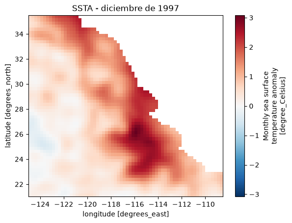

```python
ds.ssta.sel(time="1997-12").plot()
plt.title("SSTA - diciembre de 1997")
plt.show()
```

### Pon en práctica lo que aprendiste

Usa el archivo de ONI para identificar otro periodo con valores positivos grandes y haz un mapa de SSTA para uno de esos meses.

Pista: primero lee `oni_mensual_1981_2026.csv` con pandas, como hicimos en el notebook 1. No busques todavía una respuesta "correcta": el objetivo es practicar cómo conectar una pregunta con una selección temporal.

## 4. Reducir dimensiones: de un campo a una serie

Una de las ventajas de trabajar con dimensiones etiquetadas es que podemos decirle a xarray **qué dimensiones queremos reducir por nombre**.

Calculemos la anomalía media sobre todo el dominio:

```python
ssta_mean = ds.ssta.mean(
    dim=("lat", "lon"),
    skipna=True
)
```

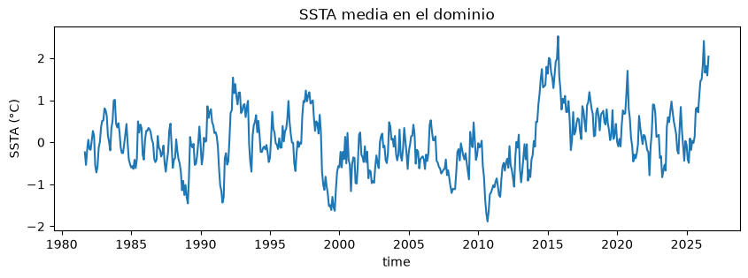

```python
ssta_mean.plot(figsize=(10, 3))
plt.ylabel("SSTA (°C)")
plt.title("SSTA media en el dominio")
plt.show()
```

Compáremos las dimensiones antes y después:

```python
ds.ssta.dims
```

```
('time', 'lat', 'lon')
```

```python
ssta_mean.dims
```

```
('time',)
```

Pasamos de:

```
(time, lat, lon)
```

a:

```
(time,)
```

porque promediamos `lat` y `lon`. Ésta es una operación muy común en análisis oceanográfico: reducir un campo espacial para construir una serie de tiempo.

`skipna=True` indica que el promedio debe ignorar valores faltantes, por ejemplo los puntos en tierra.

## 5. Seleccionar una región geográfica

El dominio completo no necesariamente corresponde a la región física que queremos estudiar. Podemos seleccionar una caja usando las coordenadas de latitud y longitud.

Usaremos una región de ejemplo al norte de la península:

```python
baja_norte = ds.ssta.sel(
    lat=slice(28, 33),
    lon=slice(-120, -115)
)

baja_norte
```

```
<xarray.DataArray 'ssta' (time: 540, lat: 20, lon: 20)> Size: 864kB
array([[[-1.050777, -0.928625, ..., -0.545403, -0.608767],
        [-0.830544, -0.698408, ..., -0.568657, -0.788465],
        ...,
        [-1.60812 , -1.423265, ...,       nan,       nan],
        [-1.275999, -1.140823, ...,       nan,       nan]],

       [[-0.895227, -0.816608, ..., -1.253399, -1.431128],
        [-0.853249, -0.721119, ..., -1.365362, -1.658245],
        ...,
        [-1.708464, -1.767599, ...,       nan,       nan],
        [-1.361904, -1.368387, ...,       nan,       nan]],

       ...,

       [[ 1.492355,  1.580235, ...,  1.319828,  1.373085],
        [ 1.526945,  1.60129 , ...,  1.364742,  1.339455],
        ...,
        [ 1.297667,  1.237612, ...,       nan,       nan],
        [ 1.119097,  0.969063, ...,       nan,       nan]],

       [[ 1.567741,  1.662237, ...,  2.600471,  2.729153],
        [ 1.525042,  1.563175, ...,  2.469732,  2.469902],
        ...,
        [ 1.946615,  2.153955, ...,       nan,       nan],
        [ 1.932486,  2.19413 , ...,       nan,       nan]]],
      shape=(540, 20, 20), dtype=float32)
Coordinates:
  * time     (time) datetime64[ns] 4kB 1981-09-01 1981-10-01 ... 2026-08-01
  * lat      (lat) float32 80B 28.12 28.38 28.62 28.88 ... 32.38 32.62 32.88
  * lon      (lon) float32 80B -119.9 -119.6 -119.4 ... -115.6 -115.4 -115.1
Attributes:
    long_name:     Monthly sea surface temperature anomaly
    units:         degree_Celsius
    source:        NOAA OISST V2.1
    cell_methods:  time: mean
    comment:       Anomaly field retained from the original course dataset. T...
```

Visualicemos primero qué seleccionamos:

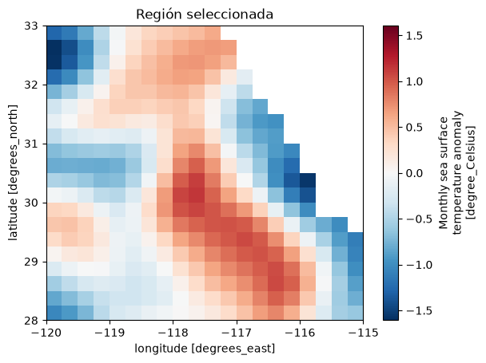

```python
baja_norte.isel(time=0).plot()
plt.title("Región seleccionada")
plt.show()
```

Y después calculemos su media espacial:

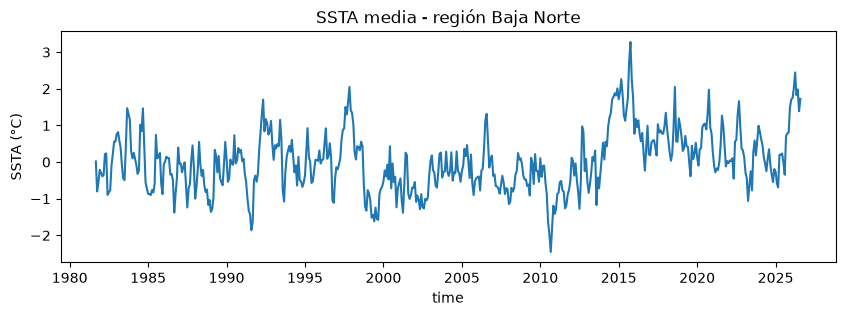

```python
baja_norte.mean(("lat", "lon"), skipna=True).plot(figsize=(10, 3))
plt.ylabel("SSTA (°C)")
plt.title("SSTA media - región Baja Norte")
plt.show()
```

> **La selección de la caja es una decisión científica, no una decisión de Python.**

> El código nos permite seleccionar cualquier región, pero debemos justificar por qué esa región responde a nuestra pregunta.

Esta libertad será importante para el proyecto final.

## 6. El puente entre xarray y pandas

Hasta ahora tenemos dos tipos de datos:

```
NetCDF → xarray → campo multidimensional de SST/SSTA
CSV    → pandas → series ONI y precipitación
```

Para compararlos podemos reducir el campo de SSTA a una serie y convertirla a un objeto de pandas.

```python
sst_series = baja_norte.mean(
    dim=("lat", "lon"),
    skipna=True
)

sst_series
```

```
<xarray.DataArray 'ssta' (time: 540)> Size: 2kB
array([ 1.74564160e-02, -8.01558197e-01, -5.48438787e-01, -2.10056201e-01,
       -3.00844878e-01, -3.91321152e-01, -3.51450324e-01,  2.18306631e-01,
        2.36718208e-01, -8.96373689e-01, -8.26660514e-01, -7.74362922e-01,
       -8.32917541e-02,  2.16435254e-01,  5.55345178e-01,  5.58817208e-01,
        7.67568827e-01,  8.17435920e-01,  5.92509389e-01,  3.92195582e-01,
       -8.96406993e-02, -4.53420550e-01, -4.91134137e-01,  4.46056247e-01,
        1.47094560e+00,  1.31415939e+00,  1.16202915e+00,  3.07478607e-01,
        1.01089582e-01,  2.49819666e-01,  9.59187672e-02, -7.72193447e-02,
       -3.22561711e-01, -2.27311581e-01,  1.01847410e+00,  8.41802597e-01,
        1.46675611e+00,  4.73688900e-01, -5.48028052e-01, -7.17218101e-01,
       -8.69918585e-01, -8.71838868e-01, -9.00755703e-01, -7.64285564e-01,
       -8.32358479e-01, -5.95172942e-01,  7.39920318e-01,  1.02240585e-01,
        1.37973234e-01,  2.48553261e-01, -5.81110537e-01, -8.74161959e-01,
       -5.98022267e-02,  1.37858000e-02,  1.45766810e-01,  1.06481969e-01,
        1.07414640e-01, -3.40419650e-01, -3.23842049e-01, -4.98340487e-01,
       -1.37972903e+00, -8.75574112e-01, -4.53465253e-01,  3.95062685e-01,
       -4.71810848e-02, -4.68279608e-02, -2.77384013e-01, -1.24894202e-01,
       -6.47406606e-03, -6.33568466e-01, -1.23914349e+00, -7.22683966e-01,
       -5.93612790e-01,  3.84082384e-02,  4.53453034e-01, -1.12486862e-01,
       -9.98680532e-01, -6.73011720e-01, -2.05730632e-01,  5.48982501e-01,
...
        9.45368707e-01,  1.02782607e+00,  1.04618251e+00,  8.91335964e-01,
        1.31337094e+00,  1.97421849e+00,  9.42699850e-01,  7.82236397e-01,
        2.48114347e-01, -1.15848340e-01, -2.80837715e-01, -1.76299915e-01,
       -2.12682039e-01,  8.36434774e-03,  4.68366623e-01,  1.26603842e+00,
        9.86229181e-01,  4.25968647e-01, -1.18900582e-01,  2.46720091e-02,
       -3.01908590e-02,  4.35215198e-02,  2.52360944e-02,  1.03148624e-01,
       -4.52163190e-01,  5.62318325e-01,  6.03779495e-01,  1.29020143e+00,
        1.66140044e+00,  9.86985683e-01,  3.67624372e-01,  3.21864456e-01,
        1.28840417e-01, -2.97220111e-01, -4.33409423e-01, -1.06257606e+00,
       -6.39319062e-01, -2.51341134e-01, -7.72708714e-01,  2.68216729e-01,
        5.86270988e-01,  1.81181297e-01,  6.09207451e-01,  9.90591884e-01,
        8.24549317e-01,  6.18465662e-01,  4.67631251e-01,  1.33606359e-01,
       -4.22421023e-02, -2.48348311e-01,  9.76257995e-02,  3.48739564e-01,
       -7.58259296e-02, -3.32571298e-01, -5.47031045e-01, -1.91240966e-01,
       -2.62534738e-01, -5.87881923e-01, -6.90237880e-01,  1.99982464e-01,
        1.95412084e-01,  2.33372405e-01, -7.88965728e-04, -3.45169932e-01,
        7.07026303e-01,  7.82383800e-01,  8.04951608e-01,  1.49029386e+00,
        1.71222687e+00,  1.74768174e+00,  2.01705718e+00,  2.44491124e+00,
        1.82997346e+00,  1.98151922e+00,  1.38823926e+00,  1.72411776e+00],
      dtype=float32)
Coordinates:
  * time     (time) datetime64[ns] 4kB 1981-09-01 1981-10-01 ... 2026-08-01
Attributes:
    long_name:     Monthly sea surface temperature anomaly
    units:         degree_Celsius
    source:        NOAA OISST V2.1
    cell_methods:  time: mean
    comment:       Anomaly field retained from the original course dataset. T...
```

```python
sst_series = sst_series.to_series()

type(sst_series)
```

```
pandas.Series
```

Ahora `sst_series` es una `pandas.Series` cuyo índice es el tiempo.

Para que este notebook pueda ejecutarse de principio a fin de manera independiente, volvemos a leer aquí los dos CSV:

```python
oni = pd.read_csv(
    "../data/oni_mensual_1981_2026.csv",
    parse_dates=["time"]
)

rain = pd.read_csv(
    "../data/precipitacion_ensenada_1981_2026.csv",
    parse_dates=["time"]
)
```

Podemos convertir `time` en el índice de cada tabla. Esto facilita alinear las tres series usando sus fechas:

```python
oni = oni.set_index("time")
rain = rain.set_index("time")
```

```python
analysis = pd.concat(
    [
        sst_series.rename("ssta_degC"),
        oni["oni_degC"],
        rain["precip_mm"]
    ],
    axis=1
)

analysis.head()
```

| time | ssta_degC | oni_degC | precip_mm |
| --- | --- | --- | --- |
| 1981-09-01 | 0.017456 | -0.25 | 2.0 |
| 1981-10-01 | -0.801558 | -0.16 | 5.0 |
| 1981-11-01 | -0.548439 | -0.13 | 68.5 |
| 1981-12-01 | -0.210056 | -0.15 | 20.0 |
| 1982-01-01 | -0.300845 | -0.08 | 54.8 |

`pd.concat(..., axis=1)` coloca las series como columnas y las alinea usando el índice temporal.

Conceptualmente acabamos de hacer:

```
NetCDF ──xarray──┐
                 ├── pandas DataFrame → análisis conjunto
CSV ────pandas───┘
```

Éste es un patrón muy común: distintas herramientas son convenientes para distintas estructuras de datos, y podemos movernos entre ellas cuando la pregunta lo requiere.

```python
analysis.info()
```

```
<class 'pandas.DataFrame'>
DatetimeIndex: 540 entries, 1981-09-01 to 2026-08-01
Data columns (total 3 columns):
 #   Column     Non-Null Count  Dtype
---  ------     --------------  -----
 0   ssta_degC  540 non-null    float32
 1   oni_degC   540 non-null    float64
 2   precip_mm  511 non-null    float64
dtypes: float32(1), float64(2)
memory usage: 14.8 KB
```

Observa que la columna de precipitación tiene menos valores válidos. `concat` no "rellena" las observaciones que faltan: conserva `NaN`, como debe ser.

## 7. Una primera comparación

Podemos empezar con una comparación visual entre ONI y la SSTA regional:

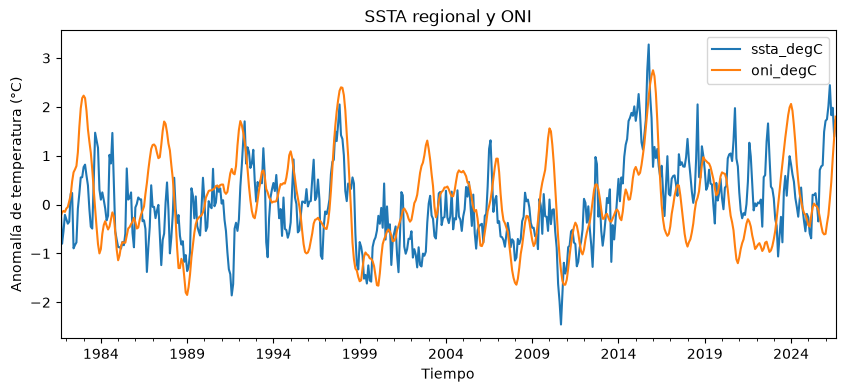

```python
analysis[["ssta_degC", "oni_degC"]].plot(figsize=(10, 4))
plt.ylabel("Anomalía de temperatura (°C)")
plt.xlabel("Tiempo")
plt.title("SSTA regional y ONI")
plt.show()
```

Otra forma de explorar la relación es mediante un diagrama de dispersión:

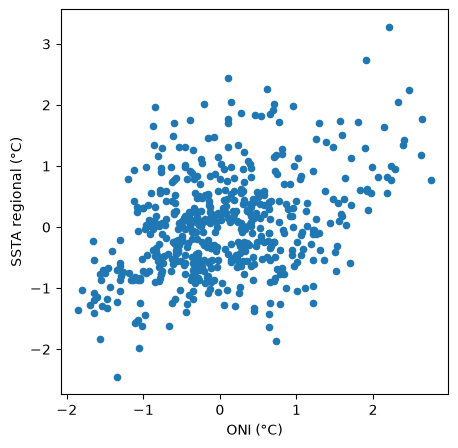

```python
analysis.plot.scatter(
    x="oni_degC",
    y="ssta_degC",
    figsize=(5, 5)
)
plt.xlabel("ONI (°C)")
plt.ylabel("SSTA regional (°C)")
plt.show()
```

Y podemos calcular una correlación lineal:

```python
analysis[["oni_degC", "ssta_degC"]].corr()
```

|  | oni_degC | ssta_degC |
| --- | --- | --- |
| oni_degC | 1.000000 | 0.390292 |
| ssta_degC | 0.390292 | 1.000000 |

**Esto es exploración, no un análisis estadístico completo.** Estas series tienen estructura temporal, persistencia y posibles desfases; además, correlación no implica causalidad. El objetivo aquí es aprender a preparar y combinar los datos de manera transparente. En el proyecto final podrán decidir qué comparación tiene sentido investigar y qué limitaciones deben mencionar.

### Pon en práctica lo que aprendiste

Elige **una** de estas exploraciones:

1. Grafica ONI y precipitación para un intervalo de tiempo que te interese.
2. Cambia la región de SSTA y repite la comparación con ONI.
3. Calcula el promedio de precipitación para las fases `"El Niño"`, `"La Niña"` y `"Neutral"` usando la función `enso_phase()` del notebook 1.
4. Explora visualmente si parece existir un desfase entre ONI y SSTA regional.

No es necesario llegar a una conclusión definitiva. Escribe debajo de tu figura dos o tres frases separando claramente **lo que observas** de **lo que interpretas**.

## 8. El problema con un notebook largo

Hasta aquí nuestra exploración funciona, pero imaginemos que mañana queremos repetir el mismo análisis para otra región.

Podríamos buscar todas las celdas donde escribimos:

```
lat=slice(28, 33)
lon=slice(-120, -115)
```

y cambiarlas a mano. Eso tiene varios problemas:

- repetimos código;
- podemos olvidar modificar una celda;
- es difícil mantener versiones consistentes;
- reutilizar el análisis en otro proyecto requiere copiar y pegar.

Como vimos en el notebook 1, una solución es **empaquetar una tarea con una función**.

## 9. Convertir una operación en una función

Primero, recordemos la operación que queremos reutilizar:

```python
region = ds.ssta.sel(
    lat=slice(28, 33),
    lon=slice(-120, -115)
)

regional_mean_example = region.mean(
    dim=("lat", "lon"),
    skipna=True
)
```

Ahora generalizamos la idea. En vez de fijar la variable y las coordenadas dentro del código, las recibimos como parámetros:

```python
def regional_mean(da, lat_range, lon_range):
    """Calcula la media espacial de un DataArray en una región rectangular.

    Parameters
    ----------
    da : xarray.DataArray
        Campo con dimensiones lat y lon.
    lat_range : tuple
        (lat_min, lat_max)
    lon_range : tuple
        (lon_min, lon_max)

    Returns
    -------
    xarray.DataArray
        Serie resultante después de promediar lat y lon.
    """

    region = da.sel(
        lat=slice(*lat_range),
        lon=slice(*lon_range)
    )

    return region.mean(
        dim=("lat", "lon"),
        skipna=True
    )
```

El operador `*` en `slice(*lat_range)` "desempaca" la tupla. Por ejemplo:

```
lat_range = (28, 33)
slice(*lat_range)
```

equivale a:

```
slice(28, 33)
```

Ahora la misma función sirve para muchas regiones:

```python
baja_series = regional_mean(ds.ssta, (28, 33), (-120, -115))

baja_series
```

```
<xarray.DataArray 'ssta' (time: 540)> Size: 2kB
array([ 1.74564160e-02, -8.01558197e-01, -5.48438787e-01, -2.10056201e-01,
       -3.00844878e-01, -3.91321152e-01, -3.51450324e-01,  2.18306631e-01,
        2.36718208e-01, -8.96373689e-01, -8.26660514e-01, -7.74362922e-01,
       -8.32917541e-02,  2.16435254e-01,  5.55345178e-01,  5.58817208e-01,
        7.67568827e-01,  8.17435920e-01,  5.92509389e-01,  3.92195582e-01,
       -8.96406993e-02, -4.53420550e-01, -4.91134137e-01,  4.46056247e-01,
        1.47094560e+00,  1.31415939e+00,  1.16202915e+00,  3.07478607e-01,
        1.01089582e-01,  2.49819666e-01,  9.59187672e-02, -7.72193447e-02,
       -3.22561711e-01, -2.27311581e-01,  1.01847410e+00,  8.41802597e-01,
        1.46675611e+00,  4.73688900e-01, -5.48028052e-01, -7.17218101e-01,
       -8.69918585e-01, -8.71838868e-01, -9.00755703e-01, -7.64285564e-01,
       -8.32358479e-01, -5.95172942e-01,  7.39920318e-01,  1.02240585e-01,
        1.37973234e-01,  2.48553261e-01, -5.81110537e-01, -8.74161959e-01,
       -5.98022267e-02,  1.37858000e-02,  1.45766810e-01,  1.06481969e-01,
        1.07414640e-01, -3.40419650e-01, -3.23842049e-01, -4.98340487e-01,
       -1.37972903e+00, -8.75574112e-01, -4.53465253e-01,  3.95062685e-01,
       -4.71810848e-02, -4.68279608e-02, -2.77384013e-01, -1.24894202e-01,
       -6.47406606e-03, -6.33568466e-01, -1.23914349e+00, -7.22683966e-01,
       -5.93612790e-01,  3.84082384e-02,  4.53453034e-01, -1.12486862e-01,
       -9.98680532e-01, -6.73011720e-01, -2.05730632e-01,  5.48982501e-01,
...
        9.45368707e-01,  1.02782607e+00,  1.04618251e+00,  8.91335964e-01,
        1.31337094e+00,  1.97421849e+00,  9.42699850e-01,  7.82236397e-01,
        2.48114347e-01, -1.15848340e-01, -2.80837715e-01, -1.76299915e-01,
       -2.12682039e-01,  8.36434774e-03,  4.68366623e-01,  1.26603842e+00,
        9.86229181e-01,  4.25968647e-01, -1.18900582e-01,  2.46720091e-02,
       -3.01908590e-02,  4.35215198e-02,  2.52360944e-02,  1.03148624e-01,
       -4.52163190e-01,  5.62318325e-01,  6.03779495e-01,  1.29020143e+00,
        1.66140044e+00,  9.86985683e-01,  3.67624372e-01,  3.21864456e-01,
        1.28840417e-01, -2.97220111e-01, -4.33409423e-01, -1.06257606e+00,
       -6.39319062e-01, -2.51341134e-01, -7.72708714e-01,  2.68216729e-01,
        5.86270988e-01,  1.81181297e-01,  6.09207451e-01,  9.90591884e-01,
        8.24549317e-01,  6.18465662e-01,  4.67631251e-01,  1.33606359e-01,
       -4.22421023e-02, -2.48348311e-01,  9.76257995e-02,  3.48739564e-01,
       -7.58259296e-02, -3.32571298e-01, -5.47031045e-01, -1.91240966e-01,
       -2.62534738e-01, -5.87881923e-01, -6.90237880e-01,  1.99982464e-01,
        1.95412084e-01,  2.33372405e-01, -7.88965728e-04, -3.45169932e-01,
        7.07026303e-01,  7.82383800e-01,  8.04951608e-01,  1.49029386e+00,
        1.71222687e+00,  1.74768174e+00,  2.01705718e+00,  2.44491124e+00,
        1.82997346e+00,  1.98151922e+00,  1.38823926e+00,  1.72411776e+00],
      dtype=float32)
Coordinates:
  * time     (time) datetime64[ns] 4kB 1981-09-01 1981-10-01 ... 2026-08-01
Attributes:
    long_name:     Monthly sea surface temperature anomaly
    units:         degree_Celsius
    source:        NOAA OISST V2.1
    cell_methods:  time: mean
    comment:       Anomaly field retained from the original course dataset. T...
```

```python
ensenada_region = regional_mean(
    ds.ssta,
    (30, 33),
    (-118, -115)
)

ensenada_region
```

```
<xarray.DataArray 'ssta' (time: 540)> Size: 2kB
array([ 3.62946577e-02, -1.18687034e+00, -8.29025805e-01, -2.63829947e-01,
       -6.14233315e-01, -4.53669995e-01, -3.65795195e-01, -1.95580438e-01,
        3.03255720e-03, -1.08906245e+00, -4.80314136e-01, -3.65696073e-01,
        3.73925269e-02,  2.40376964e-01,  3.90374213e-01,  5.25056124e-01,
        7.56639898e-01,  5.97896636e-01,  5.39421976e-01,  8.96685570e-02,
       -1.39169604e-01, -5.67946732e-01, -2.86197990e-01,  5.50798476e-01,
        1.31498802e+00,  1.07315552e+00,  1.13743627e+00,  5.64195998e-02,
        4.49751914e-02,  3.80425066e-01,  5.66140294e-01,  1.58508494e-01,
        1.61651731e-01,  3.13639730e-01,  1.56470954e+00,  1.39395130e+00,
        1.90803671e+00,  6.26028538e-01, -6.39585853e-01, -9.62161064e-01,
       -9.88233328e-01, -1.00671279e+00, -1.13069832e+00, -8.40362608e-01,
       -6.94967628e-01, -7.48120248e-01,  5.78929007e-01,  6.28157035e-02,
       -1.84798717e-01,  2.59546906e-01, -5.99936903e-01, -1.08487940e+00,
       -9.07322690e-02,  8.78633782e-02,  1.91181138e-01, -5.46693690e-02,
        1.80477574e-01, -3.66395891e-01, -5.42671025e-01, -7.76732564e-01,
       -1.59355414e+00, -9.48474705e-01, -3.37785810e-01,  5.67610860e-01,
        1.04841895e-01, -1.40318554e-02, -1.85128435e-01,  2.13046208e-01,
        5.84474578e-02, -6.95351243e-01, -1.53275263e+00, -1.05274558e+00,
       -6.88185334e-01, -2.81184256e-01,  3.84503007e-01, -3.54109436e-01,
       -1.31950200e+00, -8.33082914e-01,  6.34780377e-02,  9.08944011e-01,
...
        1.22340226e+00,  8.16568673e-01,  1.08476114e+00,  8.58179212e-01,
        1.38246810e+00,  2.30985236e+00,  1.21432519e+00,  1.10700023e+00,
        5.14360249e-01,  1.27596632e-01,  3.53533030e-02,  1.60148427e-01,
        1.54361382e-01,  4.25053149e-01,  1.13496768e+00,  1.11815774e+00,
        1.02193010e+00,  6.82282388e-01, -1.41372532e-01, -3.92025011e-03,
        5.13838306e-02,  2.96215773e-01,  2.63938159e-01,  7.80684799e-02,
       -4.89832044e-01,  8.86821926e-01,  5.01251400e-01,  1.07486308e+00,
        1.68024135e+00,  8.64592075e-01,  1.35845184e-01,  3.72110233e-02,
        2.24161148e-02, -3.63212854e-01, -5.41945577e-01, -1.08120263e+00,
       -8.59260023e-01, -4.89191324e-01, -8.57845247e-01, -3.16693872e-01,
        4.38857526e-02, -1.74302474e-01,  3.28329742e-01,  9.31417465e-01,
        6.15147293e-01,  4.01500970e-01,  3.16131830e-01, -2.70038217e-01,
       -1.34662330e-01, -3.93551320e-01, -1.70417383e-01,  1.54962003e-01,
       -3.46843123e-01, -6.64969206e-01, -9.71608102e-01, -1.20594180e+00,
       -9.34022546e-01, -7.57179499e-01, -8.82939160e-01, -1.67060375e-01,
        4.83270139e-02, -8.95957723e-02, -3.67742926e-02, -3.92212301e-01,
        3.48263562e-01,  2.09312444e-03,  1.92956388e-01,  1.36520243e+00,
        1.57076025e+00,  1.70194900e+00,  2.09488440e+00,  2.50352168e+00,
        1.67587101e+00,  1.76184404e+00,  1.15060616e+00,  1.51067805e+00],
      dtype=float32)
Coordinates:
  * time     (time) datetime64[ns] 4kB 1981-09-01 1981-10-01 ... 2026-08-01
Attributes:
    long_name:     Monthly sea surface temperature anomaly
    units:         degree_Celsius
    source:        NOAA OISST V2.1
    cell_methods:  time: mean
    comment:       Anomaly field retained from the original course dataset. T...
```

**Mismo código, distinta región.** Ésa es una de las razones principales para escribir funciones: separar la lógica general de los valores particulares de un análisis.

En programas más grandes construimos funciones pequeñas, con propósitos específicos, y las combinamos para formar tareas más complejas.

## 10. Del notebook a código reutilizable

Un notebook es muy útil para:

- explorar datos;
- probar ideas;
- combinar explicación, figuras y código;
- documentar decisiones.

Pero no queremos que una función útil exista únicamente en una celda de un notebook. Podemos moverla a un archivo de Python que otros programas puedan importar.

En JupyterLab crea:

```
scripts/
└── analysis_tools.py
```

y guarda ahí, por ejemplo:

```
def regional_mean(da, lat_range, lon_range):
    """Calcula la media espacial de un DataArray en una región rectangular."""

    region = da.sel(
        lat=slice(*lat_range),
        lon=slice(*lon_range)
    )

    return region.mean(
        dim=("lat", "lon"),
        skipna=True
    )


def enso_phase(oni_value):
    """Clasifica de manera simplificada un valor individual de ONI."""

    if oni_value >= 0.5:
        return "El Niño"
    elif oni_value <= -0.5:
        return "La Niña"
    else:
        return "Neutral"
```

Ahora tenemos un **módulo** con herramientas que podemos reutilizar desde más de un análisis.

## 11. Del notebook a un script reproducible

El siguiente paso es separar una tarea completa de exploración del notebook.

Crea:

```
scripts/
└── make_summary_figure.py
```

con el siguiente contenido:

```
import xarray as xr
import pandas as pd
import matplotlib.pyplot as plt

from analysis_tools import regional_mean


# 1. Leer datos
ds = xr.open_dataset("data/sst_baja_1981_2026.nc")

oni = pd.read_csv(
    "data/oni_mensual_1981_2026.csv",
    parse_dates=["time"]
).set_index("time")


# 2. Calcular una serie regional de SSTA
regional_ssta = regional_mean(
    ds.ssta,
    (28, 33),
    (-120, -115)
).to_series()


# 3. Alinear las series
analysis = pd.concat(
    [
        regional_ssta.rename("ssta_degC"),
        oni["oni_degC"]
    ],
    axis=1
)


# 4. Crear la figura
fig, axes = plt.subplots(
    nrows=2,
    figsize=(10, 6),
    sharex=True
)

analysis["ssta_degC"].plot(ax=axes[0])
axes[0].set_ylabel("SSTA (°C)")
axes[0].set_title("SSTA regional")

analysis["oni_degC"].plot(ax=axes[1])
axes[1].set_ylabel("ONI (°C)")
axes[1].set_xlabel("Tiempo")
axes[1].set_title("Oceanic Niño Index")

fig.tight_layout()
fig.savefig("figures/ssta_oni_summary.png", dpi=150)
```

Vuelve a la **raíz del proyecto** en la terminal y ejecuta:

```
python scripts/make_summary_figure.py
```

Si todo funciona, el script debe generar:

```
figures/
└── ssta_oni_summary.png
```

### ¿Qué ganamos?

```
Notebook
↓
explorar, probar, explicar

Función
↓
encapsular una tarea para reutilizarla

Script
↓
repetir un análisis completo
```

El notebook sigue siendo valioso: documenta la exploración y el razonamiento. El script nos permite volver a producir el resultado de forma consistente.

**Reproducibilidad** no significa sólo conservar una figura final: significa conservar los pasos necesarios para volver a crearla.

## 12. En resumen

En este notebook:

- abrimos un NetCDF con `xr.open_dataset()`;
- distinguimos `Dataset` y `DataArray`;
- usamos dimensiones, coordenadas y atributos;
- seleccionamos por posición con `.isel()` y por coordenada con `.sel()`;
- redujimos dimensiones con `.mean()`;
- seleccionamos una región geográfica;
- convertimos una serie de xarray a pandas;
- alineamos datos provenientes de NetCDF y CSV;
- hicimos una exploración gráfica y una correlación sencilla;
- convertimos una operación repetida en la función `regional_mean()`;
- separamos funciones reutilizables en `analysis_tools.py`;
- diseñamos un script que puede regenerar una figura.

### Siguiente paso

Ahora tenemos archivos que **queremos conservar, modificar y mejorar**:

```
notebooks/
scripts/
figures/
README.md
environment.yml
```

En la sesión 3 usaremos Git para registrar la historia de esos cambios y GitHub para respaldar y compartir el proyecto.

## Recursos para continuar

- [Software Carpentry: Programming with Python](https://swcarpentry.github.io/python-novice-inflammation/)
- [xarray tutorial](https://github.com/xarray-contrib/xarray-tutorial/tree/main)
- [xarray documentation](https://docs.xarray.dev/)
- [pandas documentation](https://pandas.pydata.org/docs/)
- [Jupyter](https://jupyter.org/)